# Data Manipulation in R

Simon Kønig

21/02/2020

## Installing packages

We will start out by installing and loading the very usefull collection of R packages designed for data analysis, called `tidyverse`. All packages share an underlying design philosophy, grammar, and data structures.

```r
install.packages('tidyverse')
```

```r
library('tidyverse')
```

For this data manipulation workflow, we’ll use the `boot::melanoma` package. The data consist of measurements made on patients with malignant melanoma. Each patient had their tumour removed by surgery at the Department of Plastic Surgery, University Hospital of Odense, Denmark during the period 1962 to 1977, and is documented in `?boot`.

```r
install.packages('boot')
```

```r
library('boot')
```

## First look at the data

The first step would be to discover what’s in the data.

`head` function to view first few rows from the data set.

```r
head(melanoma)
```

```
##   time status sex age year thickness ulcer
## 1   10      3   1  76 1972      6.76     1
## 2   30      3   1  56 1968      0.65     0
## 3   35      2   1  41 1977      1.34     0
## 4   99      3   0  71 1968      2.90     0
## 5  185      1   1  52 1965     12.08     1
## 6  204      1   1  28 1971      4.84     1
```

`glimpse` to view the structure of the imported data

```r
glimpse(melanoma)
```

```
## Observations: 205
## Variables: 7
## $ time      <dbl> 10, 30, 35, 99, 185, 204, 210, 232, 232, 279, 295, 355…
## $ status    <dbl> 3, 3, 2, 3, 1, 1, 1, 3, 1, 1, 1, 3, 1, 1, 1, 3, 1, 1, …
## $ sex       <dbl> 1, 1, 1, 0, 1, 1, 1, 0, 1, 0, 0, 0, 0, 1, 0, 1, 1, 1, …
## $ age       <dbl> 76, 56, 41, 71, 52, 28, 77, 60, 49, 68, 53, 64, 68, 63…
## $ year      <dbl> 1972, 1968, 1977, 1968, 1965, 1971, 1972, 1974, 1968, …
## $ thickness <dbl> 6.76, 0.65, 1.34, 2.90, 12.08, 4.84, 5.16, 3.22, 12.88…
## $ ulcer     <dbl> 1, 0, 0, 0, 1, 1, 1, 1, 1, 1, 1, 1, 1, 1, 1, 1, 1, 1, …
```

`summary` to get some descriptive statistics

```r
summary(melanoma)
```

```
##       time          status          sex              age
##  Min.   :  10   Min.   :1.00   Min.   :0.0000   Min.   : 4.00
##  1st Qu.:1525   1st Qu.:1.00   1st Qu.:0.0000   1st Qu.:42.00
##  Median :2005   Median :2.00   Median :0.0000   Median :54.00
##  Mean   :2153   Mean   :1.79   Mean   :0.3854   Mean   :52.46
##  3rd Qu.:3042   3rd Qu.:2.00   3rd Qu.:1.0000   3rd Qu.:65.00
##  Max.   :5565   Max.   :3.00   Max.   :1.0000   Max.   :95.00
##       year        thickness         ulcer
##  Min.   :1962   Min.   : 0.10   Min.   :0.000
##  1st Qu.:1968   1st Qu.: 0.97   1st Qu.:0.000
##  Median :1970   Median : 1.94   Median :0.000
##  Mean   :1970   Mean   : 2.92   Mean   :0.439
##  3rd Qu.:1972   3rd Qu.: 3.56   3rd Qu.:1.000
##  Max.   :1977   Max.   :17.42   Max.   :1.000
```

## Data Manipulation using `dplyr`

The powerfull package `dplyr` aims to provide a function for each basic step of data manipulation. The functions aids in performing most of the typical data manipulation operations:

- `filter()` to select cases based on their values.
- `arrange()` to reorder the cases.
- `select()` and `rename()` to select or rename variables based on their names.
- `mutate()` and `transmute()` to add new variables that are functions of existing variables.
- `summarise()` to condense multiple values to a single value.
- `sample_n()` and `sample_frac()` to take random samples.
- `pipe operator(%>%)` to pipe together operations.

#### Filter rows with `filter()`

`filter()` allows you to select a subset of rows in a data frame. Like all `dplyr` functions, the first argument is the tibble (or data frame). The second and subsequent arguments refer to variables within that data frame, selecting rows where the expression is `TRUE`.

For example, we can select all male subjects with age higher than or qual to 60:

```r
head(filter(melanoma, age>=60 & sex == 1))
```

```
##   time status sex age year thickness ulcer
## 1   10      3   1  76 1972      6.76     1
## 2  210      1   1  77 1972      5.16     1
## 3  426      1   1  63 1970      4.84     1
## 4  493      3   1  72 1971     12.56     1
## 5  621      1   1  72 1972      7.06     1
## 6  629      1   1  95 1968      5.48     1
```

We use head() to only display the first 6 rows

`R` provides a suite of operators that can be used when filtering data, including `>, >=, <, <=, !=, ==, & (and), | (or)`

#### Arrange rows with `arrange()`

`arrange()` works similarly to `filter()` except that instead of filtering or selecting rows, it reorders them. It takes a data frame and a set of column names (or more complicated expressions) to order by. If you provide more than one column name, each additional column will be used to break ties in the values of preceding columns. For instance we can arrange the melanoma dataframe by age first and subsequently by ulcer thinkness:

```r
head(arrange(melanoma, age, thickness))
```

```
##   time status sex age year thickness ulcer
## 1 3385      2   0   4 1968      2.74     0
## 2 3776      2   1  12 1967      7.09     1
## 3  469      1   0  14 1969      2.42     1
## 4 1710      2   1  15 1973      0.58     0
## 5  858      1   0  16 1967      3.56     0
## 6 4479      2   0  19 1965      1.13     1
```

We can use `desc()` to order a column in descending order:

```r
head(arrange(melanoma, desc(age)))
```

```
##   time status sex age year thickness ulcer
## 1  629      1   1  95 1968      5.48     1
## 2  667      1   0  89 1968     13.85     1
## 3  826      3   0  86 1965      8.54     1
## 4 1970      2   1  84 1972      4.09     1
## 5 1690      1   1  83 1971      1.62     0
## 6 1919      2   1  83 1972      3.54     0
```

#### Select columns with `select()`

Often you work with large datasets with many columns but only a few are actually of interest. `select()` allows you to zoom in on a useful subset using operations that usually only work on numeric variable positions:

`select()` is used for choosing variables based on the subset criteria. For instance to display the variables sex, age and year:

```r
head(select(melanoma, sex, age, year))
```

```
##   sex age year
## 1   1  76 1972
## 2   1  56 1968
## 3   1  41 1977
## 4   0  71 1968
## 5   1  52 1965
## 6   1  28 1971
```

or we can select all variables between age an ulcer:

```r
head(select(melanoma, age:ulcer))
```

```
##   age year thickness ulcer
## 1  76 1972      6.76     1
## 2  56 1968      0.65     0
## 3  41 1977      1.34     0
## 4  71 1968      2.90     0
## 5  52 1965     12.08     1
## 6  28 1971      4.84     1
```

or all variables except sex and age:

```r
head(select(melanoma, -(sex:age)))
```

```
##   time status year thickness ulcer
## 1   10      3 1972      6.76     1
## 2   30      3 1968      0.65     0
## 3   35      2 1977      1.34     0
## 4   99      3 1968      2.90     0
## 5  185      1 1965     12.08     1
## 6  204      1 1971      4.84     1
```

To rename columns we can use `rename()`:

```r
head(rename(melanoma, ulceration = ulcer))
```

```
##   time status sex age year thickness ulceration
## 1   10      3   1  76 1972      6.76          1
## 2   30      3   1  56 1968      0.65          0
## 3   35      2   1  41 1977      1.34          0
## 4   99      3   0  71 1968      2.90          0
## 5  185      1   1  52 1965     12.08          1
## 6  204      1   1  28 1971      4.84          1
```

#### Add new columns with `mutate()`

Besides selecting sets of existing columns, it’s often useful to add new columns that are functions of existing columns. This can be done using the function `mutate()` For instance we can create the new column sex_str where we specify the sex as a string, either male or female:

```r
head(mutate(melanoma, sex_str = ifelse(sex==0, 'female', 'male')))
```

```
##   time status sex age year thickness ulcer sex_str
## 1   10      3   1  76 1972      6.76     1    male
## 2   30      3   1  56 1968      0.65     0    male
## 3   35      2   1  41 1977      1.34     0    male
## 4   99      3   0  71 1968      2.90     0  female
## 5  185      1   1  52 1965     12.08     1    male
## 6  204      1   1  28 1971      4.84     1    male
```

or we can create a new column of tumour thickness in cm:

```r
head(mutate(melanoma, thickness_cm = thickness/10))
```

```
##   time status sex age year thickness ulcer thickness_cm
## 1   10      3   1  76 1972      6.76     1        0.676
## 2   30      3   1  56 1968      0.65     0        0.065
## 3   35      2   1  41 1977      1.34     0        0.134
## 4   99      3   0  71 1968      2.90     0        0.290
## 5  185      1   1  52 1965     12.08     1        1.208
## 6  204      1   1  28 1971      4.84     1        0.484
```

`mutate()` appends the new variable to the data frame. If you only want to keep the new variables, use `transmute()`:

```r
head(transmute(melanoma, sex_str = ifelse(sex==0, 'female', 'male'), thickness_cm = thickness/10))
```

```
##   sex_str thickness_cm
## 1    male        0.676
## 2    male        0.065
## 3    male        0.134
## 4  female        0.290
## 5    male        1.208
## 6    male        0.484
```

#### Pipe operator

When carrying out function call inside of other functions it can become a bit awkward and difficult to read and manage. To circumvent this we can use the  
`dplyr` pipe operator `%>%`. It is used to tie multiple operations together. This makes it easy, especially when we need to perform various operations on a dataset to derive the results.

For instance we can read `melanoma %>% select(sex, age)` from left to right — from the melanoma dataset, select sex and age variables. Meaning that we pipe the output from one call as input for the next.

```r
melanoma %>% select(sex, age) %>% filter(age >= 50 & sex == 1) %>% head()
```

```
##   sex age
## 1   1  76
## 2   1  56
## 3   1  52
## 4   1  77
## 5   1  63
## 6   1  72
```

Using pipe in the above makes the code easier to read compared to:

```r
head(select(filter(melanoma, age >= 50 & sex == 1 ), sex,age))
```

```
##   sex age
## 1   1  76
## 2   1  56
## 3   1  52
## 4   1  77
## 5   1  63
## 6   1  72
```

#### Group and summarise values with `summarise()` and `group_by`

`group_by` is used to group data together based on one or more columns. It is mostly useful when used along with a summarizing function to derive aggregated values for each group. For instance we can group by sex and count the observation by using the `tally()` function:

```r
melanoma %>% group_by(sex) %>% tally()
```

```
## # A tibble: 2 x 2
##     sex     n
##   <dbl> <int>
## 1     0   126
## 2     1    79
```

The power of `group_by()` comes when it is used together with the `summarize()`function which collapses each group into a single-row summary of that group by applying an aggregating or summary function to each group: So to view the mean tumour thickness for each sex:

```r
melanoma %>% group_by(sex) %>% summarise(mean_thickness = mean(thickness))
```

```
## # A tibble: 2 x 2
##     sex mean_thickness
##   <dbl>          <dbl>
## 1     0           2.49
## 2     1           3.61
```

or we can calculate some statistic measures for the parameter sex.

```r
melanoma %>%
  group_by(sex) %>%
  summarise(mean_thickness = mean(thickness),
            sd_thickness = sd(thickness),
            n_thickness = n(),
            SE_thickness = sd(thickness)/sqrt(n())) %>%
            mutate(lower_ci = mean_thickness - qt(1 - (0.05 / 2), n_thickness - 1) * SE_thickness,
            upper_ci = mean_thickness + qt(1 - (0.05 / 2), n_thickness - 1) * SE_thickness)
```

```
## # A tibble: 2 x 7
##     sex mean_thickness sd_thickness n_thickness SE_thickness lower_ci
##   <dbl>          <dbl>        <dbl>       <int>        <dbl>    <dbl>
## 1     0           2.49         2.75         126        0.245     2.00
## 2     1           3.61         3.16          79        0.355     2.90
## # … with 1 more variable: upper_ci <dbl>
```

#### Randomly sample rows with `sample_n()` and `sample_frac()`

You can use `sample_n()` and `sample_frac()` to take a random sample of rows: use `sample_n()` for a fixed number and `sample_frac()` for a fixed fraction

```r
melanoma %>% sample_n(10)
```

```
##    time status sex age year thickness ulcer
## 1  1648      2   0  55 1973      1.29     0
## 2  1933      1   0  77 1972      1.94     0
## 3  1075      1   1  66 1971      3.54     1
## 4  4688      2   0  42 1965      0.48     0
## 5  1512      2   0  77 1973      0.16     0
## 6  1548      1   0  61 1972      1.62     0
## 7   858      1   0  16 1967      3.56     0
## 8  1525      3   0  76 1970      1.29     1
## 9  2075      2   1  55 1972      2.58     1
## 10  185      1   1  52 1965     12.08     1
```

```r
melanoma %>% sample_frac(0.1)
```

```
##    time status sex age year thickness ulcer
## 1  4001      2   0  69 1967      2.10     0
## 2  2062      1   0  52 1965      3.06     0
## 3  3154      3   1  49 1969      1.62     0
## 4  3667      2   0  42 1967      3.22     0
## 5  1654      2   1  20 1973      0.97     0
## 6  2426      2   0  69 1971      3.87     0
## 7  2156      2   0  45 1972      0.97     0
## 8  2460      2   0  47 1971      0.64     0
## 9  4926      2   0  50 1964      2.26     0
## 10  204      1   1  28 1971      4.84     1
## 11  833      1   0  56 1971      2.58     1
## 12 3278      2   1  54 1969      2.58     0
## 13  279      1   0  68 1971      7.41     1
## 14 1634      2   0  68 1973      1.37     0
## 15 1641      2   0  57 1973      0.81     0
## 16  210      1   1  77 1972      5.16     1
## 17 1252      1   0  58 1971      3.87     1
## 18  355      3   0  64 1972      0.16     1
## 19 2227      2   0  51 1971      0.10     0
## 20 2108      1   0  58 1969      1.76     1
```

Use `replace = TRUE` to perform a bootstrap sample. If needed, you can weight the sample with the `weight` argument.

## Tidying data using `tidyr`

The goal of tidyr is to help you create tidy data. Tidy data is data where:

1. Each variable is in a column.
2. Each observation is a row.
3. Each value is a cell.

Tidy data describes a standard way of storing data that is used wherever possible throughout the tidyverse. If you ensure that your data is tidy, you’ll spend less time fighting with the tools and more time working on your analysis. A cheat sheet to `tidyr` can be found [here](https://github.com/rstudio/cheatsheets/blob/master/data-import.pdf)

There are four major function that can be used to tidying data:

- `gather()` takes multiple columns, and gathers them into key-value pairs: it makes “wide” data longer.
- `spread()` takes two columns (key & value), and spreads into multiple columns: it makes “long” data wider.
- ``separate()``` splits a column into multiple columns.
- `unite()` does the reverse of separate. It unites multiple columns into single column

`separate()` splits apart one column into multiple columns, by splitting wherever a separator character appears. E.g., we can split the variable `year` into two variables, called `century` and `year`. Here we specify in the seperator that we want to seperate at the second position of the year.

```r
melanoma %>% separate(year, into = c('century', 'year'), sep = 2) %>% head()
```

```
##   time status sex age century year thickness ulcer
## 1   10      3   1  76      19   72      6.76     1
## 2   30      3   1  56      19   68      0.65     0
## 3   35      2   1  41      19   77      1.34     0
## 4   99      3   0  71      19   68      2.90     0
## 5  185      1   1  52      19   65     12.08     1
## 6  204      1   1  28      19   71      4.84     1
```

```r
df <- melanoma %>% separate(year, into = c('century', 'year'), sep = 2)
head(df)
```

```
##   time status sex age century year thickness ulcer
## 1   10      3   1  76      19   72      6.76     1
## 2   30      3   1  56      19   68      0.65     0
## 3   35      2   1  41      19   77      1.34     0
## 4   99      3   0  71      19   68      2.90     0
## 5  185      1   1  52      19   65     12.08     1
## 6  204      1   1  28      19   71      4.84     1
```

With the function `unite()`, we can reverse the seperation.

```r
df %>% unite(year, century, year) %>% head()
```

```
##   time status sex age  year thickness ulcer
## 1   10      3   1  76 19_72      6.76     1
## 2   30      3   1  56 19_68      0.65     0
## 3   35      2   1  41 19_77      1.34     0
## 4   99      3   0  71 19_68      2.90     0
## 5  185      1   1  52 19_65     12.08     1
## 6  204      1   1  28 19_71      4.84     1
```

## Data visualization using `ggplot2`

It’s hard to succinctly describe how ggplot2 works because it embodies a deep philosophy of visualisation. However, in most cases you start with `ggplot()`, supply a dataset and aesthetic mapping (with `aes()`). You then add on layers (i.e. plot types like `geom_point()` to create a scatterplot or `geom_histogram()`to create a histogram), scales (like `scale_colour_brewer()`), faceting specifications (like `facet_wrap()`) and coordinate systems (like `coord_flip()`).

The general syntax of using ggplot2 will look like this:

```r
ggplot(data = <default data set>,
       aes(x = <default x axis variable>,
           y = <default y axis variable>,
           ... <other default aesthetic mappings>),
       ... <other plot defaults>) +

       geom_<geom type>(aes(size = <size variable for this geom>,
                      ... <other aesthetic mappings>),
                  data = <data for this point geom>,
                  stat = <statistic string or function>,
                  position = <position string or function>,
                  color = <"fixed color specification">,
                  <other arguments, possibly passed to the _stat_ function) +

  scale_<aesthetic>_<type>(name = <"scale label">,
                     breaks = <where to put tick marks>,
                     labels = <labels for tick marks>,
                     ... <other options for the scale>) +

  theme(plot.background = element_rect(fill = "gray"),
        ... <other theme elements>)
```

It might seem a little daunting but essentially one can create usefull plots by understanding just the first, and most important, couple of layers.

**Check out the ggplot cheatsheet [here](https://www.rstudio.com/wp-content/uploads/2015/03/ggplot2-cheatsheet.pdf)**

We start out by specifying the dataset we are working with to the `ggplot` function. Then we supply the variables that we want to plot in the `aes()` function:

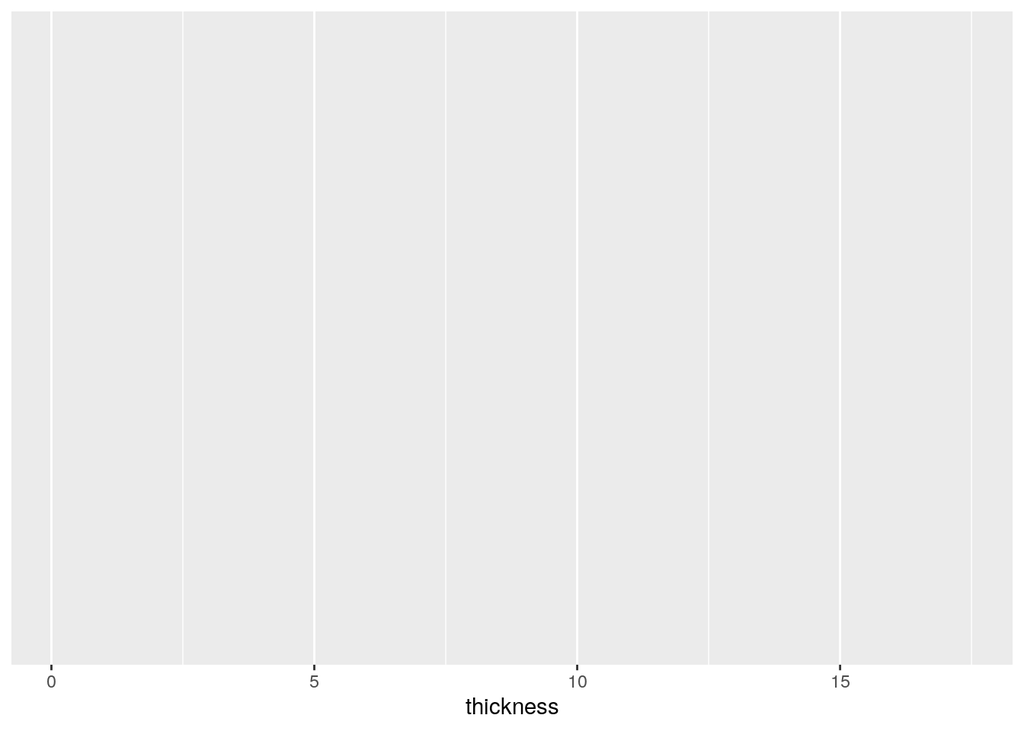

```r
ggplot(data = melanoma, mapping = aes(x = thickness))
```

Next we can add the next layer, the plot type. All plot types starts with geom_. We pipe together the layers using `+`, similarly to the pipe operator previously used.

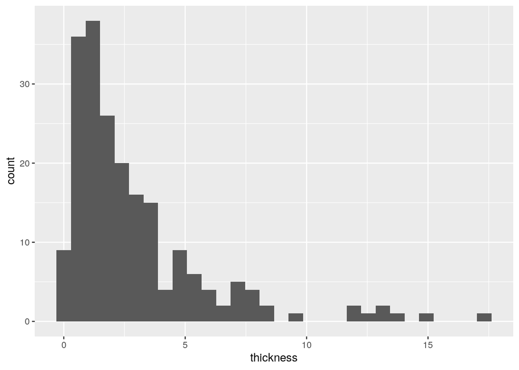

```r
ggplot(data = melanoma, mapping = aes(x = thickness)) + geom_histogram()
```

In the `geom_histogram()` layer we can specify the color and fill color of bins. We can add axis labels and title with `xlab()`, `ylab` and `ggtitle()`.

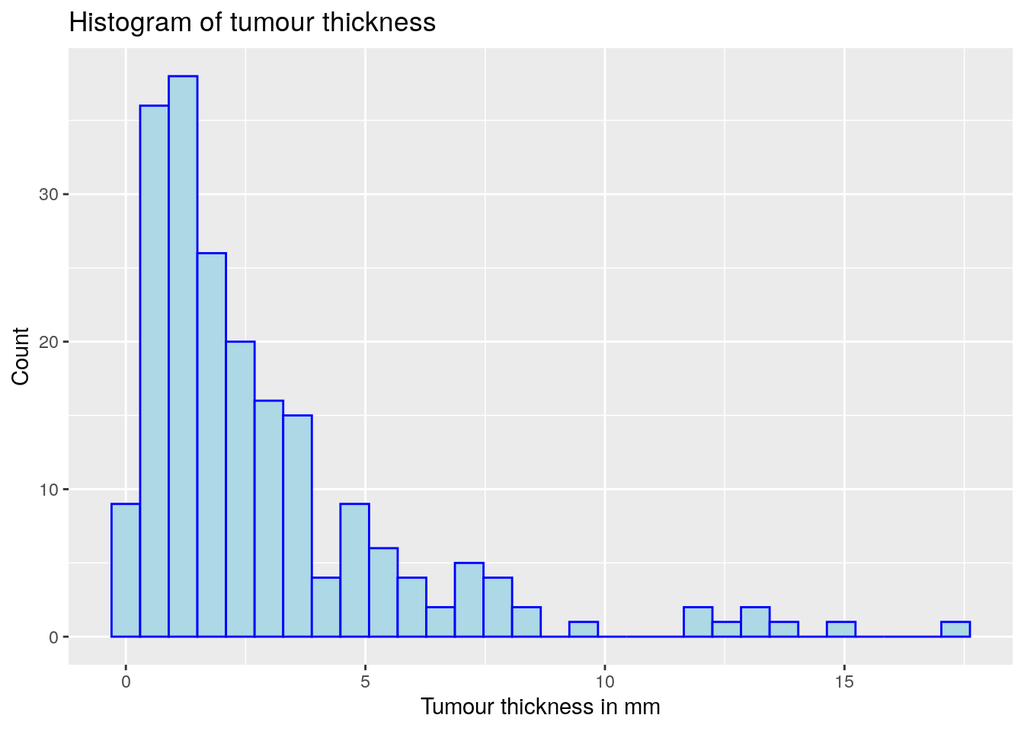

```r
ggplot(data = melanoma, mapping = aes(x = thickness)) + geom_histogram(color = 'Blue', fill = 'Lightblue') + xlab('Tumour thickness in mm') + ylab('Count') + ggtitle('Histogram of tumour thickness')
```

We can use `geom_boxplot()` to create a boxplot depicting the categorical variable status against the numerical age. To get a variable description of the melanoma dataset you can type `?melanoma` in the console. We can color the categorical groups by supplying the `aes()`function:

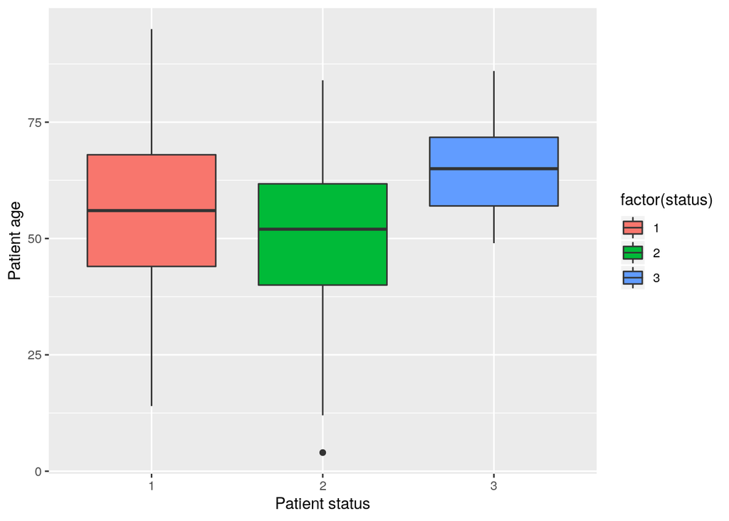

```r
ggplot(data = melanoma, mapping = aes(x = factor(status), y = age)) + geom_boxplot(aes(fill=factor(status))) + xlab('Patient status') + ylab('Patient age')
```

To create a scatter plot we supply the `geom_point()` function. We can create a scatter plot of the numerical variables `age` and `thickness` colored by `sex`:

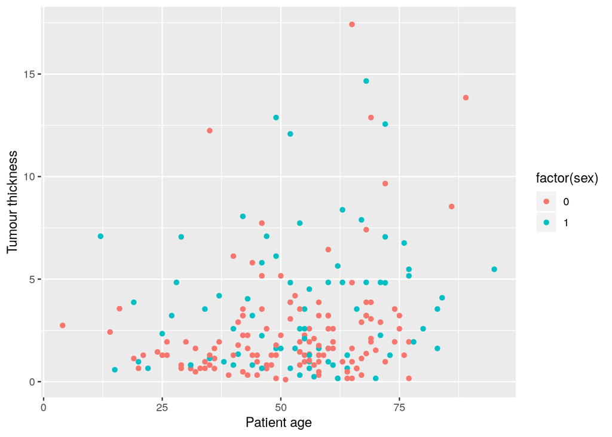

```r
ggplot(data = melanoma, mapping = aes(x = age, y = thickness)) + geom_point(aes(color=factor(sex))) + xlab('Patient age') + ylab('Tumour thickness')
```